# DT Lab

Nathan Lindley

October 20, 2022

```r
library(tidyverse)
library(mice)
library(dplyr)
library(caret)
```

```r
library(rpart.plot)
library(ROCR)
#install.packages("MLmetrics")
library(MLmetrics)
library(mltools)
library(data.table)
```

Congrats! You just graduated UVA’s MSDS program and got a job working at a movie studio in Hollywood.

Your boss is the head of the studio and wants to know if they can gain a competitive advantage by predicting new movies that might get high imdb scores (movie rating).

You would like to be able to explain the model to the mere mortals but need a fairly robust and flexible approach so you’ve chosen to use decision trees to get started.

In doing so, similar to great data scientists of the past you remembered the excellent education provided to you at UVA in a undergrad data science course and have outlined 20ish steps that will need to be undertaken to complete this task. As always, you will need to make sure to #comment your work heavily.

Footnotes: - You can add or combine steps if needed - Also, remember to try several methods during evaluation and always be mindful of how the model will be used in practice. - Make sure all your variables are the correct type (factor, character, numeric, etc.)

```r
#1 Load the data and ensure the labels are correct. restate the question and comment on evaluation metrics that you might pay attention to.
df <- read_csv("~/DS-3001/data/movie_metadata.csv")
colnames(df)
```

```
##  [1] "color"                     "director_name"
##  [3] "num_critic_for_reviews"    "duration"
##  [5] "director_facebook_likes"   "actor_3_facebook_likes"
##  [7] "actor_2_name"              "actor_1_facebook_likes"
##  [9] "gross"                     "genres"
## [11] "actor_1_name"              "movie_title"
## [13] "num_voted_users"           "cast_total_facebook_likes"
## [15] "actor_3_name"              "facenumber_in_poster"
## [17] "plot_keywords"             "movie_imdb_link"
## [19] "num_user_for_reviews"      "language"
## [21] "country"                   "content_rating"
## [23] "budget"                    "title_year"
## [25] "actor_2_facebook_likes"    "imdb_score"
## [27] "aspect_ratio"              "movie_facebook_likes"
```

```r
# Question: How can we predict which movies will receive a high IMDB score?
# Evaluation Metrics: Sensitivity, loss of movie revenue from a missed hit would be disastrous
```

```r
#2 Ensure all the variables are classified correctly including the target variable and collapse factor variables as needed.
drop_cols <- c(2,7,10,11,12,15,17,18)
df <- df[-drop_cols]
str(df)
```

```
## tibble [5,043 × 20] (S3: tbl_df/tbl/data.frame)
##  $ color                    : chr [1:5043] "Color" "Color" "Color" "Color" ...
##  $ num_critic_for_reviews   : num [1:5043] 723 302 602 813 NA 462 392 324 635 375 ...
##  $ duration                 : num [1:5043] 178 169 148 164 NA 132 156 100 141 153 ...
##  $ director_facebook_likes  : num [1:5043] 0 563 0 22000 131 475 0 15 0 282 ...
##  $ actor_3_facebook_likes   : num [1:5043] 855 1000 161 23000 NA 530 4000 284 19000 10000 ...
##  $ actor_1_facebook_likes   : num [1:5043] 1000 40000 11000 27000 131 640 24000 799 26000 25000 ...
##  $ gross                    : num [1:5043] 7.61e+08 3.09e+08 2.00e+08 4.48e+08 NA ...
##  $ num_voted_users          : num [1:5043] 886204 471220 275868 1144337 8 ...
##  $ cast_total_facebook_likes: num [1:5043] 4834 48350 11700 106759 143 ...
##  $ facenumber_in_poster     : num [1:5043] 0 0 1 0 0 1 0 1 4 3 ...
##  $ num_user_for_reviews     : num [1:5043] 3054 1238 994 2701 NA ...
##  $ language                 : chr [1:5043] "English" "English" "English" "English" ...
##  $ country                  : chr [1:5043] "USA" "USA" "UK" "USA" ...
##  $ content_rating           : chr [1:5043] "PG-13" "PG-13" "PG-13" "PG-13" ...
##  $ budget                   : num [1:5043] 2.37e+08 3.00e+08 2.45e+08 2.50e+08 NA ...
##  $ title_year               : num [1:5043] 2009 2007 2015 2012 NA ...
##  $ actor_2_facebook_likes   : num [1:5043] 936 5000 393 23000 12 632 11000 553 21000 11000 ...
##  $ imdb_score               : num [1:5043] 7.9 7.1 6.8 8.5 7.1 6.6 6.2 7.8 7.5 7.5 ...
##  $ aspect_ratio             : num [1:5043] 1.78 2.35 2.35 2.35 NA 2.35 2.35 1.85 2.35 2.35 ...
##  $ movie_facebook_likes     : num [1:5043] 33000 0 85000 164000 0 24000 0 29000 118000 10000 ...
```

```r
#3 Check for missing variables and correct as needed.
# mice::md.pattern(df)

df <- df[complete.cases(df),]

med <- median(df$imdb_score)

df <- df%>%
  mutate(aboveMedian = ifelse(df$imdb_score > med, 'True', 'False'))

df$content_rating <- make.names(df$content_rating)
df$country <- make.names(df$country)
df$color <- make.names(df$color)
df$language <- make.names(df$language)
df$aboveMedian <- make.names(df$aboveMedian)
# df = lapply(df, make.names)

factor_columns <- c(1, 12, 13, 14, 21)
df[,factor_columns] <- lapply(df[,factor_columns], as_factor)
colnames(df) <- make.names(colnames(df))
df <- df[,-18]
```

```r
#4 Guess what, you don't need to standardize the data,because DTs don't require this to be done, they make local greedy decisions...keeps getting easier, go to the next step
```

```r
#5 Determine the baserate or prevalence for the classifier, what does this number mean? (Need to cut the target appropriately)

table(df$aboveMedian)
```

```
##
##  True False
##  1746  2024
```

```r
# 0: 2024, 1: 1746, Total: 3770
# I'm assuming these are different because there are a significant number of ratings
# that are equal to the median.
prevalence = 1746/3770
prevalence # 46.3%
```

```
## [1] 0.46313
```

```r
#6 Split your data into test, tune, and train. (80/10/10)
split_index <- createDataPartition(df$aboveMedian, p=.8,
                                   list=F,
                                   times=1)

train <- df[split_index,]
dim(train)
```

```
## [1] 3017   20
```

```r
test <- df[-split_index,]
dim(test)
```

```
## [1] 753  20
```

```r
tuneTestSplit <- createDataPartition(test$aboveMedian, p=.5,
                                     list=F,
                                     times=1)

tune <- test[tuneTestSplit,]
dim(tune)
```

```
## [1] 377  20
```

```r
test <- test[tuneTestSplit,]
dim(test)
```

```
## [1] 377  20
```

```r
#7 Build your model using the training data, rpart2, and repeated cross validation as reviewed in class with the caret package.
fitControl <- trainControl(method = "repeatedcv",
                          number = 10,
                          repeats = 5,
                          classProbs = T,
                          summaryFunction = twoClassSummary)

features <- train[,-20]
target <- train$aboveMedian

tree.grid <- expand.grid(maxdepth=c(5,7,9,11))

set.seed(1999)
myDT <- train(x=features,
                y=target,
                method="rpart2",
                trControl=fitControl,
                metric="ROC")
```

[output not shown]

```r
#8 View the results, comment on how the model performed and which variables appear to be contributing the most (variable importance)
myDT
```

```
## CART
##
## 3017 samples
##   19 predictor
##    2 classes: 'True', 'False'
##
## No pre-processing
## Resampling: Cross-Validated (10 fold, repeated 5 times)
## Summary of sample sizes: 2715, 2715, 2715, 2715, 2715, 2715, ...
## Resampling results across tuning parameters:
##
##   maxdepth  ROC        Sens       Spec
##   1         0.6549838  0.3915725  0.9183951
##   3         0.7312979  0.5969723  0.8298765
##   5         0.7806783  0.6805982  0.7877778
##
## ROC was used to select the optimal model using the largest value.
## The final value used for the model was maxdepth = 5.
```

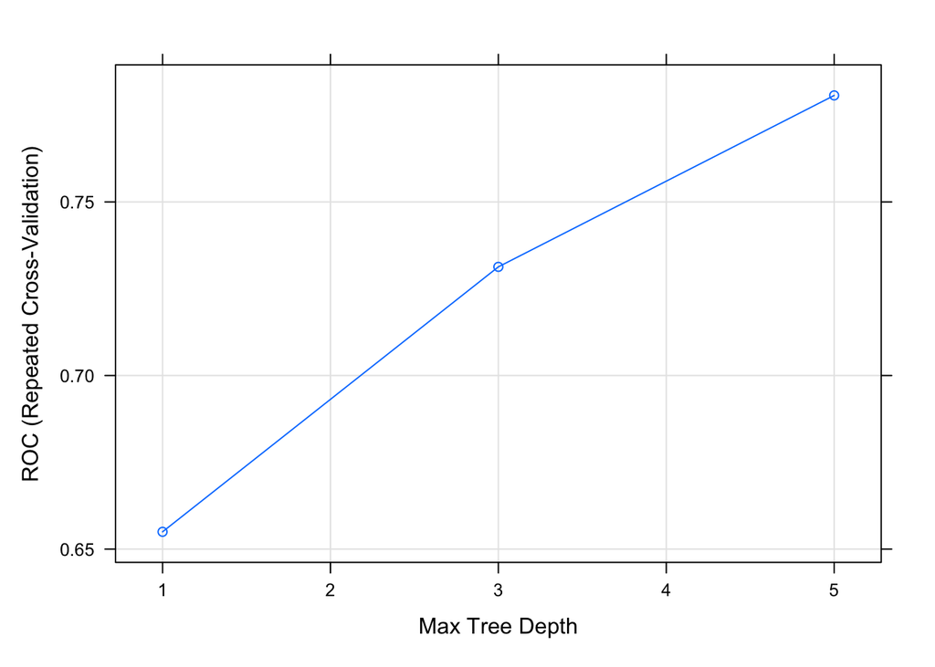

```r
plot(myDT)
```

```r
varImp(myDT)
```

```
## rpart2 variable importance
##
##                           Overall
## num_voted_users           100.000
## duration                   72.377
## budget                     63.465
## country                    60.085
## num_user_for_reviews       57.641
## movie_facebook_likes       44.373
## num_critic_for_reviews     42.753
## language                   40.873
## actor_3_facebook_likes     22.635
## actor_2_facebook_likes     15.676
## gross                      15.530
## title_year                  5.441
## cast_total_facebook_likes   4.582
## director_facebook_likes     0.000
## aspect_ratio                0.000
## content_rating              0.000
## actor_1_facebook_likes      0.000
## facenumber_in_poster        0.000
## color                       0.000
```

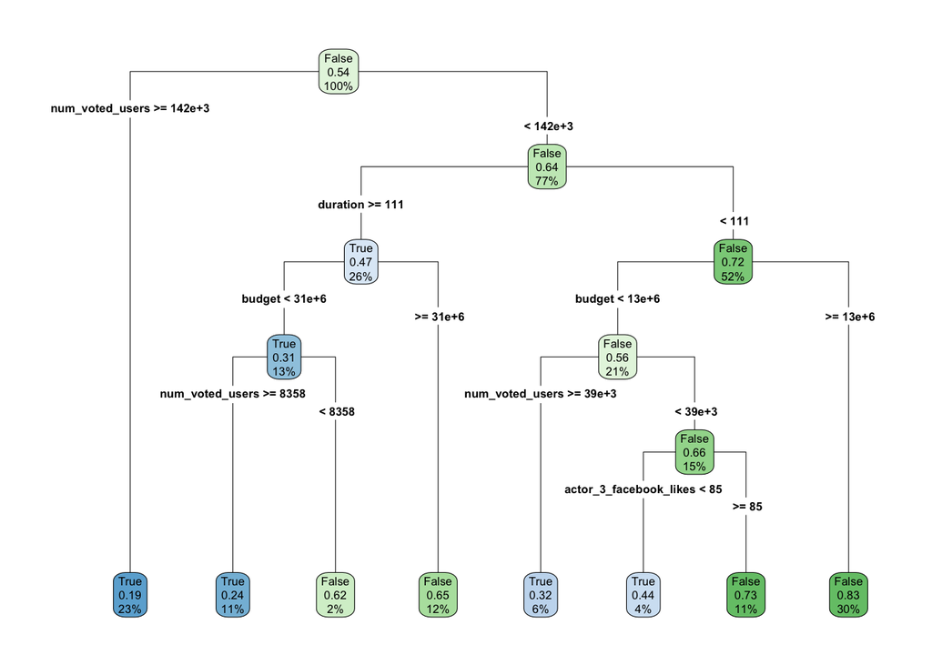

```r
#9 Plot the output of the model to see the tree visually, using rpart.plot
rpart.plot(myDT$finalModel, type=4)
```

```r
#10 Use the tune set and the predict function with your model to the
# predict the target variable, making sure to produce probabilities.
prob_pred <- predict(myDT, tune, type='prob')
prob_pred
```

```
##          True     False
## 1   0.8093842 0.1906158
## 2   0.8093842 0.1906158
## 3   0.8093842 0.1906158
## 4   0.8093842 0.1906158
## 5   0.8093842 0.1906158
## 6   0.8093842 0.1906158
## 7   0.8093842 0.1906158
## 8   0.8093842 0.1906158
## 9   0.1679389 0.8320611
## 10  0.1679389 0.8320611
## 11  0.8093842 0.1906158
## 12  0.1679389 0.8320611
## 13  0.8093842 0.1906158
## 14  0.8093842 0.1906158
```

[output cut: 363 more lines]

```r
#11 Use the the confusion matrix function on your predictions to check a variety of metrics and comment on the metric that might be best for this type of analysis given your question.
predictandCM<- function(model,data,modeltype,ref)
{
  #model using, data going into the model, and output type for predict function
  pred <-predict(model,data,type=modeltype)
  confusionMatrix(pred, reference=ref, positive = 'True')
}

predictandCM(myDT,tune,"raw",tune$aboveMedian)
```

```
## Confusion Matrix and Statistics
##
##           Reference
## Prediction True False
##      True   124    48
##      False   51   154
##
##                Accuracy : 0.7374
##                  95% CI : (0.6899, 0.7811)
##     No Information Rate : 0.5358
##     P-Value [Acc > NIR] : 6.777e-16
##
##                   Kappa : 0.4715
##
##  Mcnemar's Test P-Value : 0.8407
##
##             Sensitivity : 0.7086
##             Specificity : 0.7624
##          Pos Pred Value : 0.7209
##          Neg Pred Value : 0.7512
##              Prevalence : 0.4642
##          Detection Rate : 0.3289
##    Detection Prevalence : 0.4562
##       Balanced Accuracy : 0.7355
##
##        'Positive' Class : True
##
```